# Billionaires EDA

Daftar Orang Orang Terkaya di Dunia

```python
Latar Belakang
```

Bisnis merupakan hal yang membantu untuk menambah kekayaan. Berikut adalah data orang orang kaya beserta atribut yang bisa dianalisis menggunakan visualisasi

Objective : Mengetahui data orang kaya yang ada di dunia dengan visualisasi menggunakan statistik

Import Library

```python
import pandas as pd
import numpy as np
import matplotlib.pyplot as plt
```

import data

```python
df = pd.read_csv(r'C:\Users\asus\Desktop\Data Scientist\Latihan Data Set\Biilionare\Billionaires Statistics Dataset.csv')
```

```python
df.head()
```

|  | rank | finalWorth | category | personName | age | country | city | source | industries | countryOfCitizenship | ... | cpi_change_country | gdp_country | gross_tertiary_education_enrollment | gross_primary_education_enrollment_country | life_expectancy_country | tax_revenue_country_country | total_tax_rate_country | population_country | latitude_country | longitude_country |
| --- | --- | --- | --- | --- | --- | --- | --- | --- | --- | --- | --- | --- | --- | --- | --- | --- | --- | --- | --- | --- | --- |
| 0 | 1 | 211000 | Fashion & Retail | Bernard Arnault & family | 74.0 | France | Paris | LVMH | Fashion & Retail | France | ... | 1.1 | $2,715,518,274,227 | 65.6 | 102.5 | 82.5 | 24.2 | 60.7 | 67059887.0 | 46.227638 | 2.213749 |
| 1 | 2 | 180000 | Automotive | Elon Musk | 51.0 | United States | Austin | Tesla, SpaceX | Automotive | United States | ... | 7.5 | $21,427,700,000,000 | 88.2 | 101.8 | 78.5 | 9.6 | 36.6 | 328239523.0 | 37.090240 | -95.712891 |
| 2 | 3 | 114000 | Technology | Jeff Bezos | 59.0 | United States | Medina | Amazon | Technology | United States | ... | 7.5 | $21,427,700,000,000 | 88.2 | 101.8 | 78.5 | 9.6 | 36.6 | 328239523.0 | 37.090240 | -95.712891 |
| 3 | 4 | 107000 | Technology | Larry Ellison | 78.0 | United States | Lanai | Oracle | Technology | United States | ... | 7.5 | $21,427,700,000,000 | 88.2 | 101.8 | 78.5 | 9.6 | 36.6 | 328239523.0 | 37.090240 | -95.712891 |
| 4 | 5 | 106000 | Finance & Investments | Warren Buffett | 92.0 | United States | Omaha | Berkshire Hathaway | Finance & Investments | United States | ... | 7.5 | $21,427,700,000,000 | 88.2 | 101.8 | 78.5 | 9.6 | 36.6 | 328239523.0 | 37.090240 | -95.712891 |

5 rows × 35 columns

```python
df.info()
```

```
<class 'pandas.core.frame.DataFrame'>
RangeIndex: 2640 entries, 0 to 2639
Data columns (total 35 columns):
 #   Column                                      Non-Null Count  Dtype
---  ------                                      --------------  -----
 0   rank                                        2640 non-null   int64
 1   finalWorth                                  2640 non-null   int64
 2   category                                    2640 non-null   object
 3   personName                                  2640 non-null   object
 4   age                                         2575 non-null   float64
 5   country                                     2602 non-null   object
 6   city                                        2568 non-null   object
 7   source                                      2640 non-null   object
 8   industries                                  2640 non-null   object
 9   countryOfCitizenship                        2640 non-null   object
```

[output cut: 27 more lines]

Penjelasan tentang data

rank: The ranking of the billionaire in terms of wealth.  
finalWorth: The final net worth of the billionaire in U.S. dollars.  
category: The category or industry in which the billionaire's business operates.  
personName: The full name of the billionaire.  
age: The age of the billionaire.  
country: The country in which the billionaire resides.  
city: The city in which the billionaire resides.  
source: The source of the billionaire's wealth.  
industries: The industries associated with the billionaire's business interests.  
countryOfCitizenship: The country of citizenship of the billionaire.  
organization: The name of the organization or company associated with the billionaire.  
selfMade: Indicates whether the billionaire is self-made (True/False).  
status: "D" represents self-made billionaires (Founders/Entrepreneurs) and "U" indicates inherited or unearned wealth.  
gender: The gender of the billionaire.  
birthDate: The birthdate of the billionaire.  
lastName: The last name of the billionaire.  
firstName: The first name of the billionaire.  
title: The title or honorific of the billionaire.  
date: The date of data collection.  
state: The state in which the billionaire resides.  
residenceStateRegion: The region or state of residence of the billionaire.  
birthYear: The birth year of the billionaire.  
birthMonth: The birth month of the billionaire.  
birthDay: The birth day of the billionaire.  
cpi_country: Consumer Price Index (CPI) for the billionaire's country.  
cpi_change_country: CPI change for the billionaire's country.  
gdp_country: Gross Domestic Product (GDP) for the billionaire's country.  
gross_tertiary_education_enrollment: Enrollment in tertiary education in the billionaire's country.  
gross_primary_education_enrollment_country: Enrollment in primary education in the billionaire's country.  
life_expectancy_country: Life expectancy in the billionaire's country.  
tax_revenue_country_country: Tax revenue in the billionaire's country.  
total_tax_rate_country: Total tax rate in the billionaire's country.  
population_country: Population of the billionaire's country.  
latitude_country: Latitude coordinate of the billionaire's country.  
longitude_country: Longitude coordinate of the billionaire's country.

kita coba cek apakah ada null atau tidak beserta jumlahnya

```python
df.isnull().sum()
```

```
rank                       0
finalWorth                 0
category                   0
personName                 0
age                       65
country                   38
city                      72
source                     0
industries                 0
countryOfCitizenship       0
organization               0
selfMade                   0
status                     0
gender                     0
birthDate                 76
lastName                   0
firstName                  3
title                   2301
date                       0
dtype: int64
```

kita coba ganti untuk organization menggunakan fillna

```python
df['organization'].fillna('unknown', inplace = True)
```

kita hilangkan data yang tidak diperlukan

```python
df.drop(['birthYear',
         'state',
         'residenceStateRegion',
         'birthYear',
         'birthMonth',
         'birthDay',
         'cpi_country',
         'cpi_change_country',
         'gdp_country',
         'gross_tertiary_education_enrollment',
         'gross_primary_education_enrollment_country',
         'life_expectancy_country',
         'tax_revenue_country_country',
         'total_tax_rate_country',
         'population_country',
         'latitude_country',
         'longitude_country'],inplace = True)
```

melihat dari kategori negara , negara mana saja secara total tertinggi ?

```python
wealth_by_country = df.groupby('country')['finalWorth'].agg('sum').sort_values(ascending = False).head(5)
wealth_by_country
```

```
country
United States    4575100
China            1805500
India             628700
France            499500
Germany           462100
Name: finalWorth, dtype: int64
```

Dari data diatas : Amerika menjadi negara dengan penghasil orang terkaya terbesar disusul dengan negara dari asia yaitu china dan india serta dilanjutkan oleh negara dari benua eropa yaitu france dan germany

Para Milyader berusaha di category usaha apa saja ? kita coba cek dengan diagram

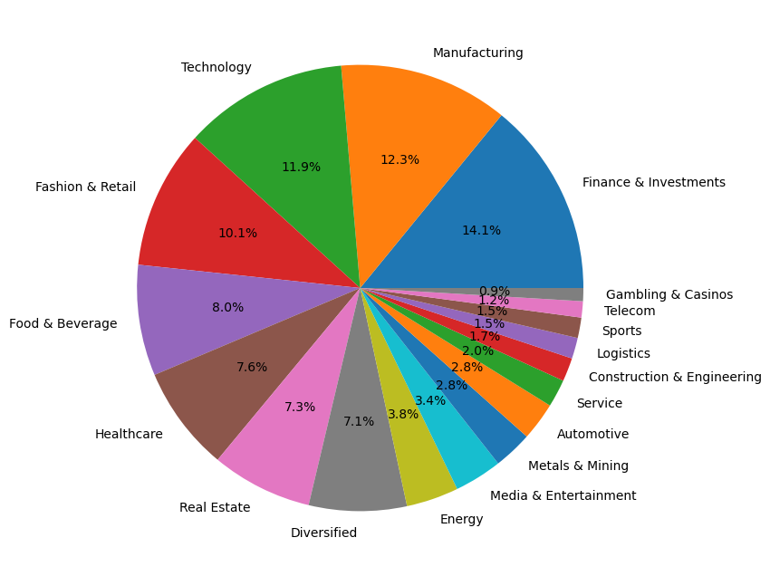

```python
category_count = df['category'].value_counts()
plt.figure (figsize=(8,8))
plt.pie(category_count,
        labels = category_count.index,
        autopct = '%1.1f%%')
plt.show()
```

dari data diatas didapatkan bahwa 5 kategori teratas yaitu

1. finance dan investment dengan 14,1 %
2. manufacturing 12.3 %
3. technology 11.9 %
4. fashion retail 10.1%
5. food and beverage 8%

bagaimana jika dilihat dari total kekayaannya?

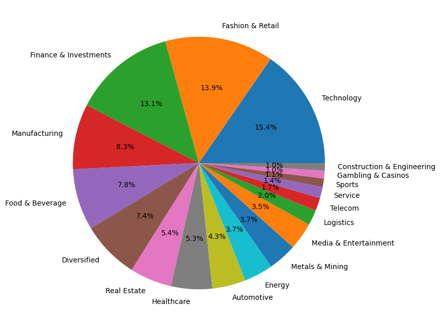

```python
# berapa banyak total kekayaan apabila 5 hal tersebut digabungkan
wealth_5_best_category = df.groupby('category')['finalWorth'].agg('sum').sort_values(ascending=False)
plt.figure(figsize=(8,8))
plt.pie(wealth_5_best_category,
        labels = wealth_5_best_category.index,
        autopct = '%1.1f%%')
plt.show()
```

jika dilihat dari total kekayaan, maka 5 terbesar adalah

1. technology
2. fashion and retail
3. finance and investment
4. manufacturing
5. food and beverage

dapat disimpulkan dari kategori yang dipilih dan total kekayaan ada di 5 kategori perbedaan hanya pada posisinya saja (bisa diteliti lebih lanjut)

berapa rata rata umur para milyader ?

```
rata rata dan nilai tengah umur : mean      65.140194
median    65.000000
Name: age, dtype: float64
paling banyak berumur : 60.0
```

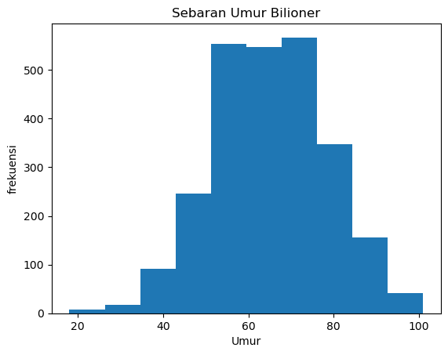

```python
print('rata rata dan nilai tengah umur :',df['age'].agg(['mean','median']))
print ('paling banyak berumur :',df['age'].mode().iloc[0])

plt.hist(df['age'])
plt.title('Sebaran Umur Bilioner')
plt.xlabel ('Umur')
plt.ylabel ('frekuensi')
```

dari grafik menyebutkan bahwa umur para bilionere terpusat antara 50-70  
tapi tak menutup kemungkinan ada yang berumur dibawah 30 tahun. kita cek siapa saja mereka dan bisnis di category apa?

```python
bilionere_under_30 =df.loc[df['age']<=30,['personName','category']]
print (bilionere_under_30)
```

```
                      personName               category
36               Mark Mateschitz        Food & Beverage
823         Clemente Del Vecchio       Fashion & Retail
824   Leonardo Maria Del Vecchio       Fashion & Retail
825             Luca Del Vecchio       Fashion & Retail
1159        Gustav Magnar Witzoe        Food & Beverage
1334         Kevin David Lehmann       Fashion & Retail
1559               Michal Strnad          Manufacturing
1754                Kim Jung-min  Media & Entertainment
1755               Kim Jung-youn  Media & Entertainment
1768               Palmer Luckey             Technology
1908          Alexandra Andresen            Diversified
1909          Katharina Andresen            Diversified
2113                 Wang Zelong        Metals & Mining
2290                 Ben Francis       Fashion & Retail
2414                Ryan Breslow             Technology
```

oke kita kan udah tau nih histiogram dari umur, kita mau ngecek apakah kekayaan ada hubungan korelasi dengan kekayaan

1. cek distribusi umur
- mean , median , modus
- quartile 1 , quartile 3
- interquartile , standar deviasi , range

```python
print('rata rata dan nilai tengah umur :',df['age'].agg(['mean','median']))
print ('paling banyak berumur :',df['age'].mode().iloc[0])
```

```
rata rata dan nilai tengah umur : mean      65.140194
median    65.000000
Name: age, dtype: float64
paling banyak berumur : 60.0
```

```python
Q1= df['age'].quantile(0.25)
Q3= df['age'].quantile(0.75)
print ('Nilai Quartile 1 :',Q1)
print ('Nilai Quartile 3 :',Q3)
```

```
Nilai Quartile 1 : 56.0
Nilai Quartile 3 : 75.0
```

```python
inter_quartile = Q3-Q1
print ('Nilai Inter Quartile :', inter_quartile)
Umur_maksimal = df['age'].max()
Umur_minimal = df['age'].min()
jarak_umur = Umur_maksimal-Umur_minimal
print ('Nilai range :',jarak_umur)
```

```
Nilai Inter Quartile : 19.0
Nilai range : 83.0
```

```python
# standar deviation
standar_deviasi_umur = df['age'].std()
print ('nilai standar deviasi umur :',standar_deviasi_umur)
```

```
nilai standar deviasi umur : 13.258097610684342
```

anlisis deskriptifnya adalah  
mean di 65  
median di 65  
maodus di 60  
Q1 56  
Q2 75  
interquartile 19  
jarak 83  
standar deviasi 13,25

Kita coba cari apakah ada korelasi antara umur dengan kekayaan

```
Nilai Korelasi : 0.06705284808355105
```

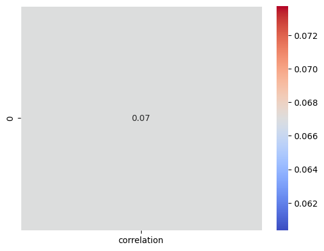

```python
import seaborn as sns
wealth_correlation = df['finalWorth'].corr(df['age'])
print ('Nilai Korelasi :',wealth_correlation)

correlation_df = pd.DataFrame(data=[[wealth_correlation]],columns=['correlation'])

sns.heatmap(correlation_df,annot=True,cmap='coolwarm', fmt=".2f", linewidths=.5) # ini gak bisa karena heatmap harus 2 d caranya adalah

plt.show()
```

```python
dari data diatas ada hubungan lemah antara umur dengan kekayaan.
```